# Lab 4

Aleksi Patronen

2024-02-05

## Metropolis-Hastings

a.) The function normm is simulating from a normal with zero mean and unit variance using a Metropolis algorithm with uniform proposal distribution. The exercise is to try the following a = 0.1,1 and 200 for 2000 iterations. Present trace plots of line type and histograms with interpretations. Tune the sampler by finding a value of a that gives an acceptance probability of 0.3. You have to modify the code in order to save the acceptance rate. Explain the code with comments.

```r
normm<-function (Nsim, a) # give the n. of simulations and the a rate. that is the acceptance rate.
{       vec <- vector("numeric", Nsim) # create an vector where the simulation results are stored
        x <- 0 # Init value
        vec[1] <- x # put init value to the vector that stores the resultsa
        for (i in 2:Nsim) { # start the for loop that goes from 2 to the Nsim
                innov <- runif(1, -a, a) # sample from uniform[-a, a]
                Xstar <- x + innov # proposal plus random walk element innov
                aprob <- min(1, dnorm(Xstar)/dnorm(x)) # aprov rate
                u <- runif(1) # sample the minumum that must be cleared, so that the proposal is accepted.
                if (u < aprob)  # if proposal less than u, proposal is not accepted and the previuous x remains
                        x <- Xstar # if proposal is accepted the x* becomes the x
                vec[i] <- x # save the new or old x into the vector.
        }
        vec #return the vector so it can be put on plot, to show the underlying distribution.
}
```

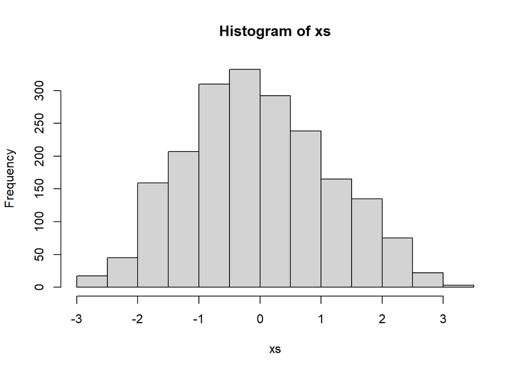

```r
#lets try it out with 2000 samples

xs <- normm(2*10^3, 1)
hist(xs)
```

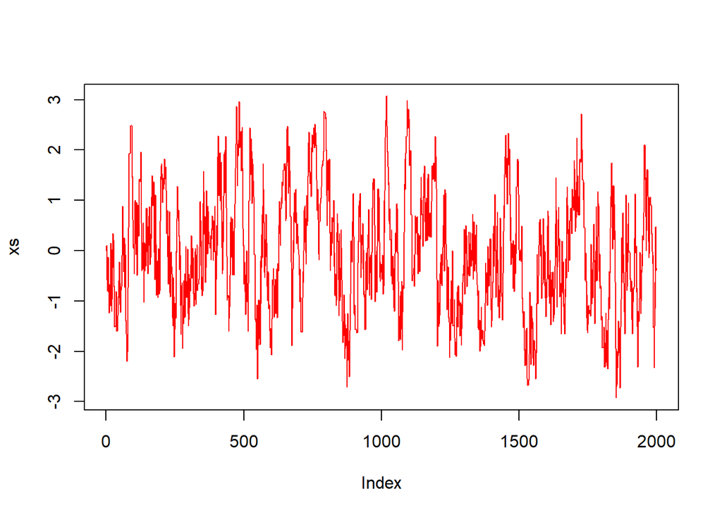

```r
plot(xs, type = "l", col = "red")
```

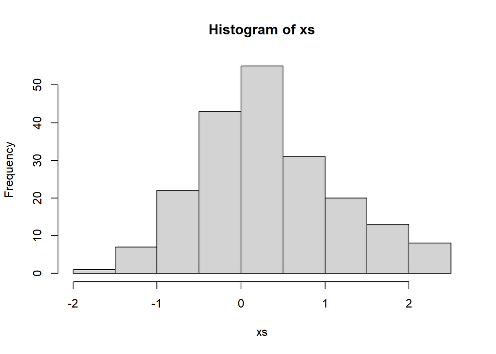

```r
xs <- normm(2*10^2, 1)
hist(xs)
```

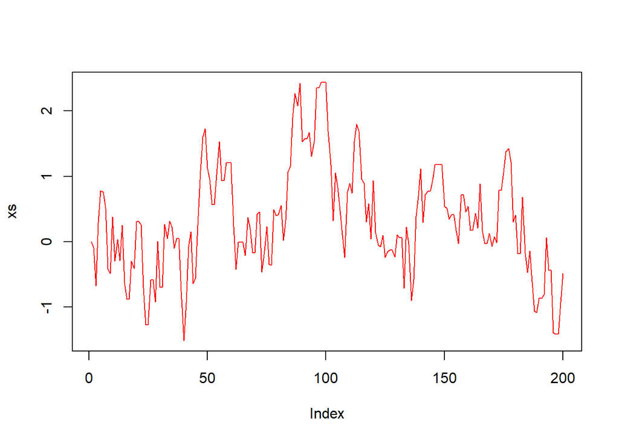

```r
plot(xs, type = "l", col = "red")
```

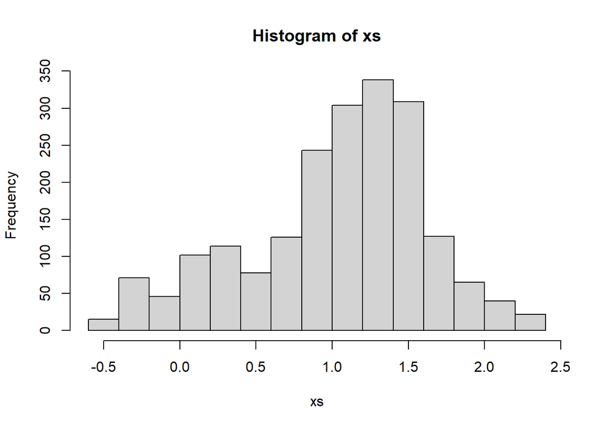

```r
xs <- normm(2*10^3, 0.1)
hist(xs)
```

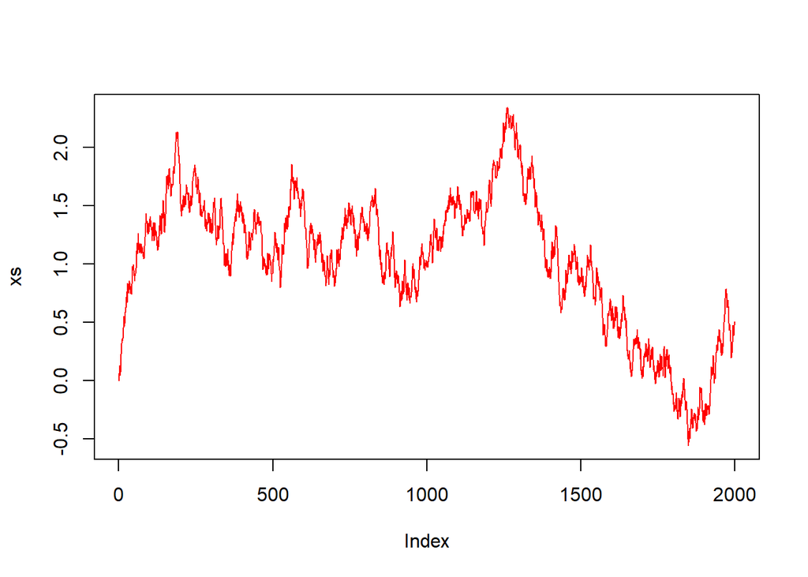

```r
plot(xs, type = "l", col = "red")
```

When a is 0.1, the algorithm doesn’t stabilize, but wanders around.

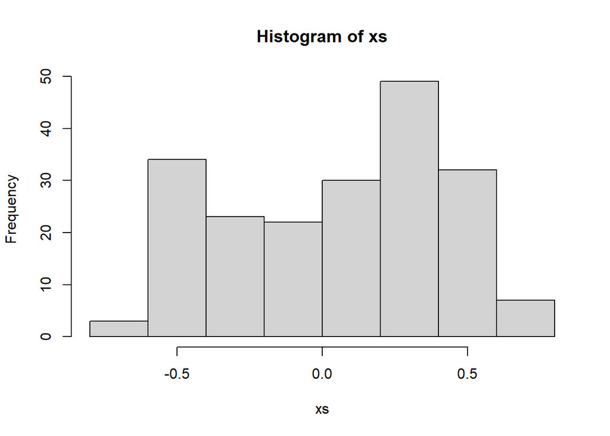

```r
xs <- normm(2*10^2, 0.1)
hist(xs)
```

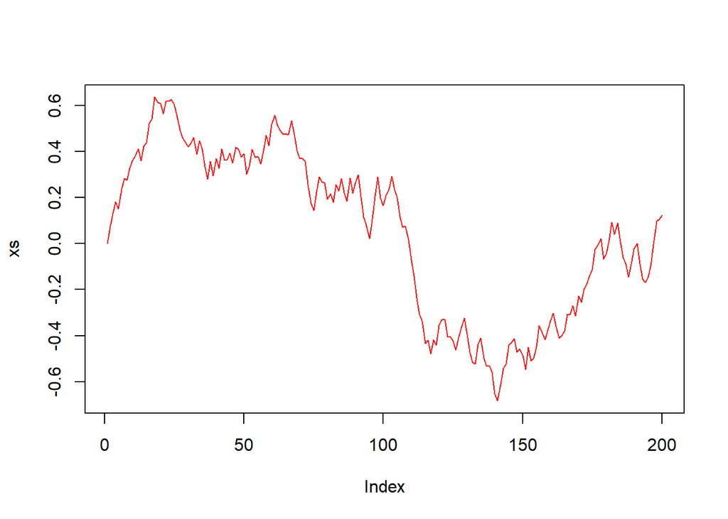

```r
plot(xs, type = "l", col = "red")
```

Aight, let’s modify normm() so that we can observe the acceptance rate

```r
normm<-function (Nsim, a)
{
        vec <- vector("numeric", Nsim)
        x <- 0
        vec[1] <- x
        N_acc = 0
        for (i in 2:Nsim) {
                innov <- runif(1, -a, a)
                Xstar <- x + innov
                aprob <- min(1, dnorm(Xstar)/dnorm(x))
                u <- runif(1)
                if (u < aprob) {
                  x <- Xstar
                  N_acc = N_acc + 1 # it is sufficient that we count the times the proposal is accepted
                  }
                vec[i] <- x
        }
        return(list(res = vec, acc = N_acc/Nsim)) #return the vector and the acceptance rate. It is no the number of time the proposal was accepted divided by the proposal numbers that is the same as Nsim.

}

results <- normm(10^3,1)
results$acc
```

```
## [1] 0.817
```

```r
results <- normm(10^3,0.1)
results[2]
```

```
## $acc
## [1] 0.991
```

```r
library(dplyr)
results <- normm(10^3, 1)
a <- 1
r <- 0.30
v <- 0.001
learning_rate = 0.001

while(!between(results$acc, r-v,r+v) ){
  a = a + learning_rate
  results <- normm(2*10^3, a)
}
print(a)
```

```
## [1] 4.939
```

```r
print(results$acc)
```

```
## [1] 0.3
```

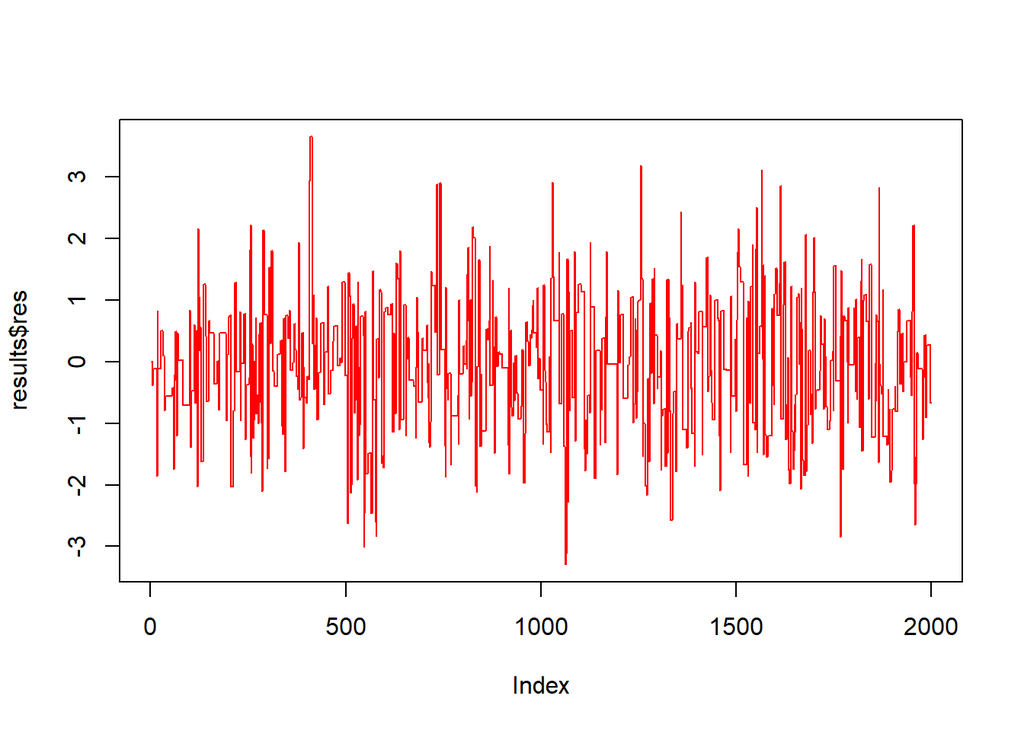

```r
plot(results$res, type = "l", col = "red")
```

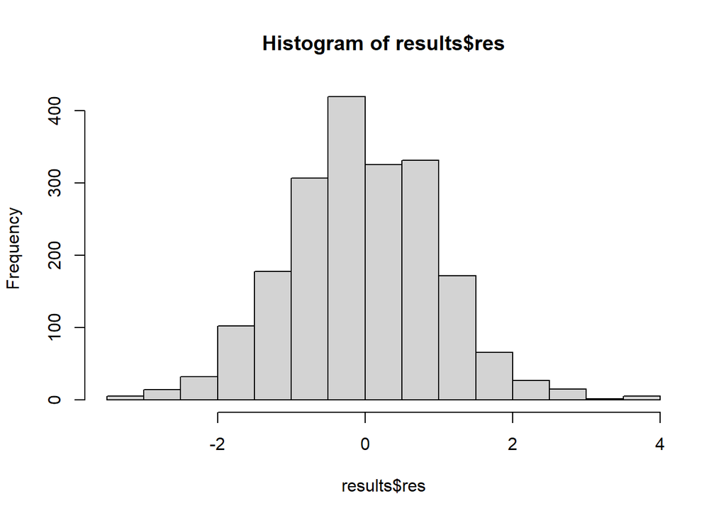

```r
hist(results$res)
```

b.) Function gammh is a Metropolis-Hastings independence sampling algorithm with normal proposal distribution with the same mean and variance as the desired gamma. Try a = 0.1, 2 and b = 0.01, 2. Present trace plots and histograms with interpretations. Explain the code with comments.

```r
gammh<-function (Nsim, a, b) {
        mu <- a/b # intit  the expected value from which the candidate is drawn from in Markov Chain
        sig <- sqrt(a/(b * b)) # init the distributions variance
        vec <- vector("numeric", Nsim) # make a vector where the simulation results are stored
        x <- a/b # init the value as give by the user.
        vec[1] <- x # First 'result' is the
        for (i in 2:Nsim) { # for loop from the second iteration to the Nsim
             can <- rnorm(1, mu, sig) # sample a candiate
             aprob <- min(1, (dgamma(can, a, b)/dgamma(x, a, b))/(dnorm(can, mu, sig)/dnorm(x,mu, sig))) # approval rate
                u <- runif(1) # sample aprov minumum
                if (u < aprob)  # if the ratior is larger than the approval minmun
                        x <- can # then accept the new value
                vec[i] <- x # if not the retain the previuys value
        }
        vec # return the vector
}
```

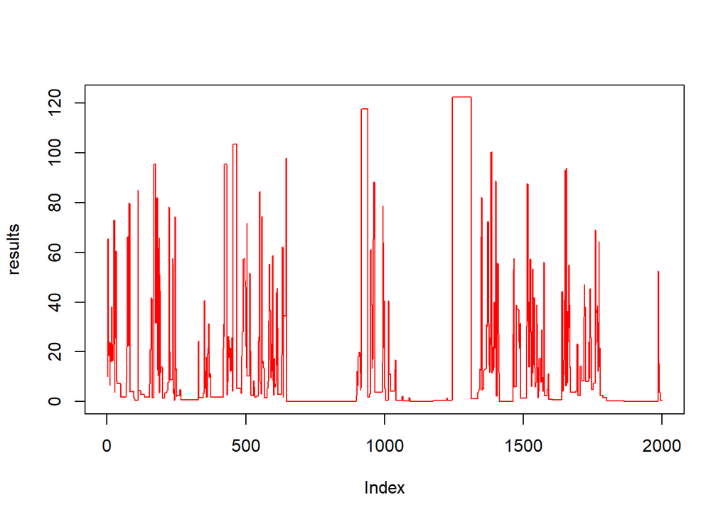

```r
results <- gammh(2*10^3, 0.1, 0.01)

plot(results, type = "l", col = "red")
```

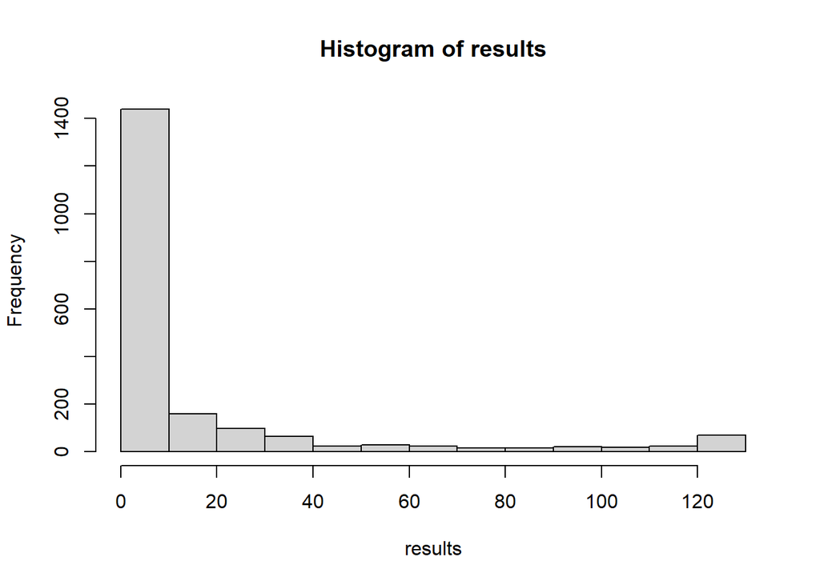

```r
hist(results)
```

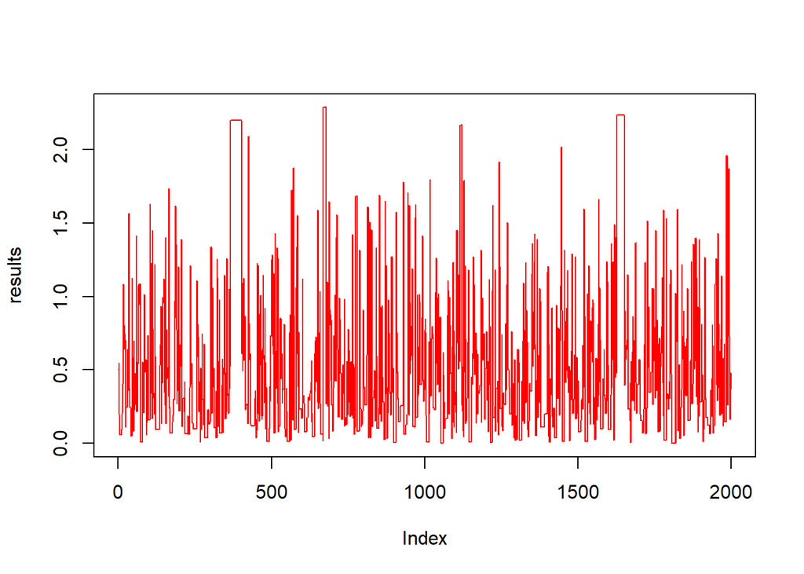

```r
results <- gammh(2*10^3, 1, 2)

plot(results, type = "l", col = "red")
```

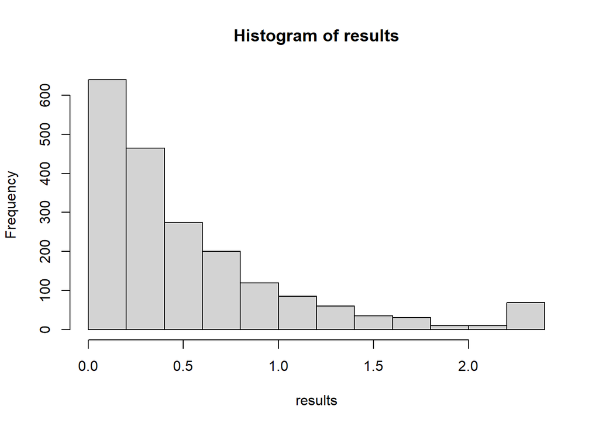

```r
hist(results)
```

# Assignment 2: Bayesian model selection using the Metropolis-Hastings algorithm

The task in this assignment is to use the code from Example 6.8 (p. 188-192 in Robert and Casella, 2009) to analyse the housing.txt data that you used in Lab 3 with marginal Bayesian model selection. Read through the example carefully so you understand if any changes need to be done to the code. Run the MH sampler for 25 000 iterations and discard the first 5 000 as burn-in, i.e. the sample to analyse should be the last 20 000 iterations. Calculate the probability that each variable is included within the model and find the model probabilities of the 5 best models (Hint: use the data.frame() and table() functions). Compare your results with those from the Simulated annealing and Genetic algorithms.

```r
housing <- read.csv("C:/Users/Aleksi/Desktop/KOulu/Simulation Methods/Exercises/exercise 4/housing.txt", sep="")
dim(housing)
```

```
## [1] 508  21
```

```r
head(housing, 6)
```

```
##   OBS.       TOWN TOWN. TRACT      LON     LAT MEDV CMEDV    CRIM ZN INDUS CHAS
## 1    1     Nahant     0  2011 -70.9550 42.2550 24.0  24.0 0.00632 18  2.31    0
## 2    2 Swampscott     1  2021 -70.9500 42.2875 21.6  21.6 0.02731  0  7.07    0
## 3    3 Swampscott     1  2022 -70.9360 42.2830 34.7  34.7 0.02729  0  7.07    0
## 4    4 Marblehead     2  2031 -70.9280 42.2930 33.4  33.4 0.03237  0  2.18    0
## 5    5 Marblehead     2  2032 -70.9220 42.2980 36.2  36.2 0.06905  0  2.18    0
## 6    6 Marblehead     2  2033 -70.9165 42.3040 28.7  28.7 0.02985  0  2.18    0
##     NOX    RM  AGE    DIS RAD TAX PTRATIO      B LSTAT
## 1 0.538 6.575 65.2 4.0900   1 296    15.3 396.90  4.98
## 2 0.469 6.421 78.9 4.9671   2 242    17.8 396.90  9.14
## 3 0.469 7.185 61.1 4.9671   2 242    17.8 392.83  4.03
## 4 0.458 6.998 45.8 6.0622   3 222    18.7 394.63  2.94
## 5 0.458 7.147 54.2 6.0622   3 222    18.7 396.90  5.33
## 6 0.458 6.430 58.7 6.0622   3 222    18.7 394.12  5.21
```

```r
y=log(as.vector(na.omit(housing[,7])))
X=as.matrix(na.omit(housing[,9:21]))

length(y)
```

```
## [1] 506
```

```r
nrow(X)
```

```
## [1] 506
```

```r
#This function inverses an matrix
inv=function(X){
  EV=eigen(X)
  EV$vector%*%diag(1/EV$values)%*%t(EV$vector)
}


#log-marginal density of model gamma
lpostw=function(gam,y,X,beta){
  n=length(y)
  qgam=sum(gam)
  Xt1=cbind(rep(1,n),X[,which(gam==1)])
  if (qgam!=0) P1=Xt1%*%inv(t(Xt1)%*%Xt1)%*%t(Xt1) else{
  P1=matrix(0,n,n)}
  -(qgam+1)/2*log(n+1)-n/2*log(t(y)%*%y-n/(n+1)*
  t(y)%*%P1%*%y-1/(n+1)*t(beta)%*%t(cbind(rep(1,n),
  X))%*%P1%*%cbind(rep(1,n),X)%*%beta)
}

#The Metropolis-Hasting algorithm itself.
gocho=function(niter,y,X){
  lga=dim(X)[2]
  beta=lm(y~X)$coeff
  gamma=matrix(0,nrow=niter,ncol=lga)
  gamma[1,]=sample(c(0,1),lga,rep=T)
    for (t in 1:(niter-1)){
      j=sample(1:lga,1)
      gam0=gam1=gamma[t,];gam1[j]=1-gam0[j]
      pr=lpostw(gam0,y,X,beta)
      pr=c(pr,lpostw(gam1,y,X,beta))
      pr=exp(pr-max(pr))
      gamma[t+1,]=gam0
    if (sample(c(0,1),1,prob=pr)){
        gamma[t+1,]=gam1
        }
      }
  gamma
}
```

```r
out <- gocho(25*10^3, y = y, X = X)
```

```r
#5000 burn-in
out <- out[5000:25000,]
```

```r
adm <- ifelse(apply(out,2,mean) < 0.5,0, 1)
adm
```

```
##  [1] 1 1 0 1 0 1 0 1 1 1 1 1 1
```

$\gamma$-vector would by the admission probabilities be [1 1 0 1 0 1 0 1 1 1 1 1 1]. Meaning INDUS, NOX and Age variables were not included in the models.

```r
res <- data.frame(out)
```

```r
summary(res)
```

```
##        X1          X2          X3                X4               X5
##  Min.   :1   Min.   :1   Min.   :0.00000   Min.   :0.0000   Min.   :0.0000
##  1st Qu.:1   1st Qu.:1   1st Qu.:0.00000   1st Qu.:1.0000   1st Qu.:0.0000
##  Median :1   Median :1   Median :0.00000   Median :1.0000   Median :0.0000
##  Mean   :1   Mean   :1   Mean   :0.03135   Mean   :0.9996   Mean   :0.1577
##  3rd Qu.:1   3rd Qu.:1   3rd Qu.:0.00000   3rd Qu.:1.0000   3rd Qu.:0.0000
##  Max.   :1   Max.   :1   Max.   :1.00000   Max.   :1.0000   Max.   :1.0000
##        X6          X7               X8               X9             X10
##  Min.   :1   Min.   :0.0000   Min.   :0.0000   Min.   :0.000   Min.   :1
##  1st Qu.:1   1st Qu.:0.0000   1st Qu.:1.0000   1st Qu.:0.000   1st Qu.:1
##  Median :1   Median :0.0000   Median :1.0000   Median :1.000   Median :1
##  Mean   :1   Mean   :0.3388   Mean   :0.9996   Mean   :0.697   Mean   :1
##  3rd Qu.:1   3rd Qu.:1.0000   3rd Qu.:1.0000   3rd Qu.:1.000   3rd Qu.:1
##  Max.   :1   Max.   :1.0000   Max.   :1.0000   Max.   :1.000   Max.   :1
##       X11         X12              X13
##  Min.   :1   Min.   :0.0000   Min.   :1
##  1st Qu.:1   1st Qu.:1.0000   1st Qu.:1
##  Median :1   Median :1.0000   Median :1
##  Mean   :1   Mean   :0.9268   Mean   :1
##  3rd Qu.:1   3rd Qu.:1.0000   3rd Qu.:1
##  Max.   :1   Max.   :1.0000   Max.   :1
```

In the lab3 simulated annealing gave results of = [0,1,0, 1, 0, 1, 0, 1, 0, 1, 1, 1, 1] and in GA

[1,1,0,1,0,1,1,1,1,1,1,1,1].

```r
MH <- c(1, 1, 0, 1, 0, 1, 0, 1, 1, 1, 1, 1, 1)
SA <- c(0, 1, 0, 1, 0, 1, 0, 1, 0, 1, 1, 1, 1)
GA <- c(1, 1, 0, 1, 0, 1, 1, 1, 1, 1 ,1, 1, 1)


MH - SA
```

```
##  [1] 1 0 0 0 0 0 0 0 1 0 0 0 0
```

```r
MH - GA
```

```
##  [1]  0  0  0  0  0  0 -1  0  0  0  0  0  0
```

Results of the different algorithms only differ in one or two places.